# Classification analysis (titanic data)

## Libraries and settings

```python
# Libraries
import os
import numpy as np
import pandas as pd
import seaborn as sns
import matplotlib.pyplot as plt
from IPython.display import Image

from sklearn import tree
from sklearn.metrics import RocCurveDisplay
from sklearn.tree import DecisionTreeClassifier
from sklearn.ensemble import RandomForestClassifier
from sklearn.model_selection import train_test_split
from sklearn.metrics import classification_report, confusion_matrix

# Ignore warnings
import warnings
warnings.filterwarnings('ignore')

# Show current working directory
print(os.getcwd())
```

```
C:\Users\adria\DA\Ex\DataAnalytics\9
```

## Import titanic data

```python
# Read and select variables
df_titanic_orig = pd.read_csv("titanic.csv", sep=",", encoding="utf-8")

# Number of rows and columns
print(df_titanic_orig.shape)

# First records
df_titanic_orig.head(5)
```

```
(891, 12)
```

|  | PassengerId | Survived | Pclass | Name | Sex | Age | SibSp | Parch | Ticket | Fare | Cabin | Embarked |
| --- | --- | --- | --- | --- | --- | --- | --- | --- | --- | --- | --- | --- |
| 0 | 1 | 0 | 3 | Braund, Mr. Owen Harris | male | 22.0 | 1 | 0 | A/5 21171 | 7.2500 | NaN | S |
| 1 | 2 | 1 | 1 | Cumings, Mrs. John Bradley (Florence Briggs Th... | female | 38.0 | 1 | 0 | PC 17599 | 71.2833 | C85 | C |
| 2 | 3 | 1 | 3 | Heikkinen, Miss. Laina | female | 26.0 | 0 | 0 | STON/O2. 3101282 | 7.9250 | NaN | S |
| 3 | 4 | 1 | 1 | Futrelle, Mrs. Jacques Heath (Lily May Peel) | female | 35.0 | 1 | 0 | 113803 | 53.1000 | C123 | S |
| 4 | 5 | 0 | 3 | Allen, Mr. William Henry | male | 35.0 | 0 | 0 | 373450 | 8.0500 | NaN | S |

## Variable description

- PassengerId passenger identification number
- Survival survival status (0 = No; 1 = Yes)
- Pclass passenger class (1 = 1st; 2 = 2nd; 3 = 3rd)
- Name name
- Sex sex
- Age age
- SibSp number of siblings/spouses aboard
- Parch number of parents/children aboard
- Ticket ticket number
- Fare passenger fare (British pound)
- Cabin cabin
- Embarked port of embarkation (C = Cherbourg; Q = Queenstown; S = Southampton)

[figure not shown]

```python
Image("img.jpg", width='100%')
```

## Count and remove missing values

```python
# Count missing values
print(df_titanic_orig.isna().sum())

# Remove missing values
df_titanic = df_titanic_orig.dropna(subset=['Survived', 'Sex', 'Age', 'Pclass', 'Fare'])
```

```
PassengerId      0
Survived         0
Pclass           0
Name             0
Sex              0
Age            177
SibSp            0
Parch            0
Ticket           0
Fare             0
Cabin          687
Embarked         2
dtype: int64
```

## Barchart survival status count by gender

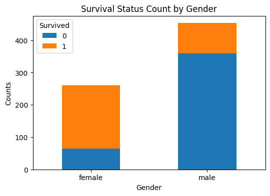

```python
# Create a pivot table
table = df_titanic[['Sex', 'Survived']].pivot_table(index='Sex',
                                        columns=['Survived'],
                                        aggfunc=len)

# Plot a stacked bar chart
table.plot(kind='bar',
           stacked=True,
           ylabel='Counts',
           xlabel='Gender',
           title='Survival Status Count by Gender',
           rot=0,
           figsize=(6,4))

plt.show()
```

## Pivot table

```python
# Using pivot_table to reshape the data and calculate means
pd.pivot_table(df_titanic[['Survived',
                           'Age',
                           'Sex',
                           'Fare',
                           'Pclass']],
               index=['Survived', 'Sex'],
               values=['Age', 'Fare', 'Pclass'],
               aggfunc=(np.mean, 'count')).round(0)
```

| Survived | Sex | Age count | Age mean | Fare count | Fare mean | Pclass count | Pclass mean |
| --- | --- | --- | --- | --- | --- | --- | --- |
| 0 | female | 64 | 25.0 | 64 | 23.0 | 64 | 3.0 |
|  | male | 360 | 32.0 | 360 | 23.0 | 360 | 2.0 |
| 1 | female | 197 | 29.0 | 197 | 56.0 | 197 | 2.0 |
|  | male | 93 | 27.0 | 93 | 44.0 | 93 | 2.0 |

## Transform nominal variable to matrix with 0/1 values

```python
male = pd.get_dummies(df_titanic, drop_first=False, columns=['Sex'])
male[['Sex_female', 'Sex_male']].head()
```

|  | Sex_female | Sex_male |
| --- | --- | --- |
| 0 | 0 | 1 |
| 1 | 1 | 0 |
| 2 | 1 | 0 |
| 3 | 1 | 0 |
| 4 | 0 | 1 |

## Create binary variable 'Sex_male' (wth 0=no, 1=yes)

```python
df_titanic['Sex_male'] = male['Sex_male']
df_titanic.head()
```

|  | PassengerId | Survived | Pclass | Name | Sex | Age | SibSp | Parch | Ticket | Fare | Cabin | Embarked | Sex_male |
| --- | --- | --- | --- | --- | --- | --- | --- | --- | --- | --- | --- | --- | --- |
| 0 | 1 | 0 | 3 | Braund, Mr. Owen Harris | male | 22.0 | 1 | 0 | A/5 21171 | 7.2500 | NaN | S | 1 |
| 1 | 2 | 1 | 1 | Cumings, Mrs. John Bradley (Florence Briggs Th... | female | 38.0 | 1 | 0 | PC 17599 | 71.2833 | C85 | C | 0 |
| 2 | 3 | 1 | 3 | Heikkinen, Miss. Laina | female | 26.0 | 0 | 0 | STON/O2. 3101282 | 7.9250 | NaN | S | 0 |
| 3 | 4 | 1 | 1 | Futrelle, Mrs. Jacques Heath (Lily May Peel) | female | 35.0 | 1 | 0 | 113803 | 53.1000 | C123 | S | 0 |
| 4 | 5 | 0 | 3 | Allen, Mr. William Henry | male | 35.0 | 0 | 0 | 373450 | 8.0500 | NaN | S | 1 |

## Classification Tree

For details see: https://scikit-learn.org/stable/modules/generated/sklearn.tree.DecisionTreeClassifier.html

```python
# Create train and test samples
X_train, X_test, y_train, y_test = train_test_split(df_titanic[['Age',
                                                                'Sex_male',
                                                                'Pclass',
                                                                'Fare']],
                                                                df_titanic['Survived'],
                                                                test_size=0.5,
                                                                random_state=42)

# Show X_train
print('X_train:')
print(X_train.head(), '\n')

# Show y_train
print('y_train:')
print(y_train.head())
```

```
X_train:
      Age  Sex_male  Pclass     Fare
339  45.0         1       1  35.5000
193   3.0         1       2  26.0000
156  16.0         0       3   7.7333
624  21.0         1       3  16.1000
426  28.0         0       2  26.0000

y_train:
339    0
193    1
156    1
624    0
426    1
Name: Survived, dtype: int64
```

### Fit the classification tree model and make predictions

```python
# Initialize the classification tree model
clf = DecisionTreeClassifier(random_state=20,
                             max_depth=8)

# Train the classification tree model
clf = clf.fit(X_train, y_train)

# Make model predictions
y_pred = clf.predict(X_test)
y_pred
```

```
array([1, 1, 1, 1, 0, 0, 1, 1, 0, 0, 1, 1, 1, 0, 1, 0, 0, 1, 0, 1, 0, 0,
       0, 0, 0, 0, 0, 0, 0, 0, 0, 0, 1, 0, 0, 0, 0, 0, 0, 0, 0, 0, 1, 0,
       0, 1, 1, 0, 0, 1, 1, 1, 1, 0, 0, 1, 0, 1, 0, 0, 1, 0, 1, 0, 0, 0,
       0, 1, 0, 1, 0, 1, 0, 0, 0, 0, 0, 0, 0, 0, 0, 1, 0, 0, 0, 0, 0, 0,
       0, 0, 0, 1, 1, 0, 1, 1, 1, 1, 0, 0, 1, 1, 0, 1, 1, 0, 0, 0, 0, 1,
       1, 0, 0, 0, 0, 0, 1, 0, 0, 0, 1, 0, 0, 0, 1, 0, 0, 1, 0, 1, 0, 0,
       0, 1, 0, 0, 0, 1, 0, 0, 0, 1, 1, 0, 0, 1, 0, 0, 0, 0, 1, 0, 0, 1,
       0, 0, 0, 0, 1, 0, 0, 0, 0, 1, 0, 1, 1, 0, 1, 0, 0, 1, 0, 1, 0, 1,
       0, 0, 0, 0, 1, 1, 1, 1, 0, 0, 1, 0, 1, 0, 1, 1, 1, 1, 0, 1, 0, 0,
       1, 0, 0, 0, 0, 0, 0, 0, 1, 0, 0, 1, 0, 0, 1, 0, 0, 0, 1, 0, 0, 0,
       0, 0, 0, 0, 0, 1, 0, 0, 0, 1, 0, 1, 0, 1, 0, 1, 0, 1, 0, 1, 1, 0,
       0, 0, 0, 0, 0, 0, 1, 1, 0, 1, 0, 0, 0, 1, 0, 0, 1, 1, 0, 1, 0, 0,
       0, 0, 0, 1, 0, 1, 0, 1, 0, 0, 0, 0, 0, 1, 0, 0, 1, 0, 0, 0, 0, 0,
       0, 0, 0, 0, 0, 0, 0, 0, 1, 1, 0, 0, 0, 1, 1, 1, 0, 1, 0, 0, 0, 0,
       1, 1, 1, 1, 0, 0, 1, 0, 0, 0, 0, 0, 0, 1, 0, 0, 1, 0, 0, 0, 0, 0,
       1, 1, 0, 0, 1, 0, 1, 1, 1, 0, 1, 0, 0, 1, 0, 0, 1, 0, 1, 0, 0, 1,
       1, 0, 0, 0, 1], dtype=int64)
```

### Show confusion matrix and classification report

```python
# Confusion matrix
print('Confusion matrix')
print(confusion_matrix(y_test, y_pred), '\n')

# Classification report
print('Classification report')
print(classification_report(y_test, y_pred))
```

```
Confusion matrix
[[184  24]
 [ 51  98]]

Classification report
              precision    recall  f1-score   support

           0       0.78      0.88      0.83       208
           1       0.80      0.66      0.72       149

    accuracy                           0.79       357
   macro avg       0.79      0.77      0.78       357
weighted avg       0.79      0.79      0.79       357
```

### Print text representation of the classification tree

```python
# Text representation of the classification tree
text_rep = tree.export_text(clf,
                            feature_names=list(X_train.columns))

# Print text_representation
print(text_rep)
```

```
|--- Sex_male <= 0.50
|   |--- Pclass <= 2.50
|   |   |--- Age <= 5.00
|   |   |   |--- Fare <= 88.78
|   |   |   |   |--- class: 1
|   |   |   |--- Fare >  88.78
|   |   |   |   |--- class: 0
|   |   |--- Age >  5.00
|   |   |   |--- Fare <= 26.12
|   |   |   |   |--- Age <= 37.00
|   |   |   |   |   |--- Age <= 27.50
|   |   |   |   |   |   |--- Age <= 26.00
|   |   |   |   |   |   |   |--- class: 1
|   |   |   |   |   |   |--- Age >  26.00
|   |   |   |   |   |   |   |--- Fare <= 15.75
|   |   |   |   |   |   |   |   |--- class: 1
|   |   |   |   |   |   |   |--- Fare >  15.75
|   |   |   |   |   |   |   |   |--- class: 0
|   |   |   |   |   |--- Age >  27.50
|   |   |   |   |   |   |--- class: 1
|   |   |   |   |--- Age >  37.00
|   |   |   |   |   |--- Age <= 39.00
|   |   |   |   |   |   |--- class: 0
|   |   |   |   |   |--- Age >  39.00
|   |   |   |   |   |   |--- Fare <= 25.96
|   |   |   |   |   |   |   |--- class: 1
|   |   |   |   |   |   |--- Fare >  25.96
|   |   |   |   |   |   |   |--- Age <= 43.00
|   |   |   |   |   |   |   |   |--- class: 1
|   |   |   |   |   |   |   |--- Age >  43.00
|   |   |   |   |   |   |   |   |--- class: 0
|   |   |   |--- Fare >  26.12
|   |   |   |   |--- class: 1
|   |--- Pclass >  2.50
|   |   |--- Fare <= 23.09
|   |   |   |--- Age <= 27.50
|   |   |   |   |--- Fare <= 7.76
|   |   |   |   |   |--- class: 1
|   |   |   |   |--- Fare >  7.76
|   |   |   |   |   |--- Age <= 6.00
```

[output cut: 84 more lines]

```
|   |   |   |   |   |   |--- Age >  28.50
|   |   |   |   |   |   |   |--- Fare <= 9.49
|   |   |   |   |   |   |   |   |--- class: 0
|   |   |   |   |   |   |   |--- Fare >  9.49
|   |   |   |   |   |   |   |   |--- class: 1
|   |   |   |   |   |--- Age >  32.50
|   |   |   |   |   |   |--- Age <= 39.50
|   |   |   |   |   |   |   |--- Age <= 38.50
|   |   |   |   |   |   |   |   |--- class: 0
|   |   |   |   |   |   |   |--- Age >  38.50
|   |   |   |   |   |   |   |   |--- class: 0
|   |   |   |   |   |   |--- Age >  39.50
|   |   |   |   |   |   |   |--- class: 0
|   |   |   |   |--- Fare >  51.70
|   |   |   |   |   |--- class: 1
```

## Visualize the classification tree

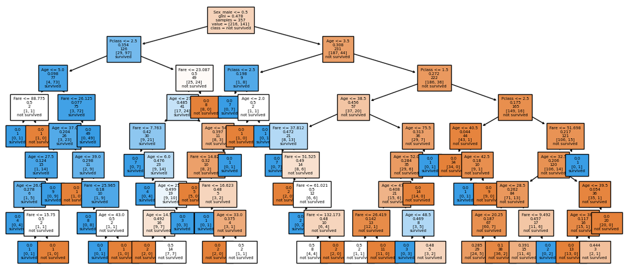

```python
# For the meaning of numbers in boxes see root node
fig = plt.figure(figsize=(14,6))
tree_plot = tree.plot_tree(clf,
                   feature_names=list(X_train.columns),
                   class_names=['not survived', 'survived'],
                   filled=True,
                   fontsize=5,
                   label='root')
```

## Random Forest Classifier

For details see: https://scikit-learn.org/stable/modules/generated/sklearn.ensemble.RandomForestClassifier.html

### Create train and test samples (train = 80%, test = 20% of the data)

```python
# Create train and test samples
X2_train, X2_test, y2_train, y2_test = train_test_split(df_titanic[[
                                                                    'Pclass',
                                                                    'Fare']],
                                                        df_titanic['Survived'],
                                                        test_size=0.20,
                                                        random_state=42)

# Show X2_train
print('X2_train:')
print(X2_train.head(), '\n')

# Show y2_train
print('y2_train:')
print(y2_train.head())
```

```
X2_train:
     Pclass     Fare
328       3  20.5250
73        3  14.4542
253       3  16.1000
719       3   7.7750
666       2  13.0000

y2_train:
328    1
73     0
253    0
719    0
666    0
Name: Survived, dtype: int64
```

### Fit the Random Forest Classifier

```python
# Initialize the random forest classifier
rfc = RandomForestClassifier(random_state=20, max_depth=10)

# Train the random forest classifier
rfc = rfc.fit(X2_train, y2_train)

# Predict the target variable (0 = not survived, 1 = survived)
y_pred_rf = rfc.predict(X2_test)

print('Predicted target variable (0 = not survived, 1 = survived)')
y_pred_rf
```

```
Predicted target variable (0 = not survived, 1 = survived)
```

```
array([0, 1, 0, 1, 0, 0, 1, 1, 0, 0, 1, 0, 1, 0, 1, 0, 0, 1, 0, 1, 0, 0,
       0, 1, 0, 0, 0, 1, 0, 0, 0, 0, 1, 0, 0, 0, 0, 0, 0, 0, 1, 0, 1, 1,
       1, 0, 0, 0, 0, 1, 1, 0, 1, 1, 0, 0, 1, 1, 0, 0, 0, 0, 1, 0, 0, 1,
       1, 1, 0, 0, 0, 1, 1, 0, 1, 0, 0, 0, 0, 1, 0, 1, 0, 0, 0, 0, 0, 0,
       0, 0, 0, 1, 0, 0, 1, 0, 1, 1, 0, 0, 0, 0, 0, 0, 0, 0, 0, 1, 0, 0,
       1, 0, 1, 1, 0, 1, 1, 1, 0, 0, 0, 0, 0, 0, 1, 0, 0, 0, 1, 0, 0, 0,
       0, 0, 0, 0, 0, 0, 0, 0, 0, 0, 1], dtype=int64)
```

### Show confusion matrix and classification report

```python
# Confusion matrix
print('Confusion matrix')
print(confusion_matrix(y2_test, y_pred_rf), '\n')

# Classification report
print('Classification report')
print(classification_report(y2_test, y_pred_rf))
```

```
Confusion matrix
[[70 17]
 [28 28]]

Classification report
              precision    recall  f1-score   support

           0       0.71      0.80      0.76        87
           1       0.62      0.50      0.55        56

    accuracy                           0.69       143
   macro avg       0.67      0.65      0.66       143
weighted avg       0.68      0.69      0.68       143
```

### Show feature importance

```
Index(['Fare', 'Pclass'], dtype='object')
[0.86079732 0.13920268]
```

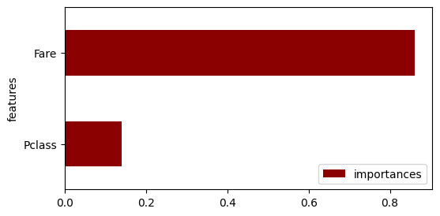

```python
cols = X2_train.columns

# Derive feature importance from random forest
importances = rfc.feature_importances_
std = np.std([tree.feature_importances_ for tree in rfc.estimators_], axis=0)
indices = np.argsort(importances)[::-1]

# Print col-names and importances-values
print( cols[indices] )
print( importances[indices] )

# Barplot with feature importance
df_fi = pd.DataFrame({'features':cols,'importances': importances})
df_fi.sort_values('importances', inplace=True)
df_fi.plot(kind='barh',
           y='importances',
           x='features',
           color='darkred',
           figsize=(6,3))
```

The Fare is now the most important feature.

### ROC curve and AUC

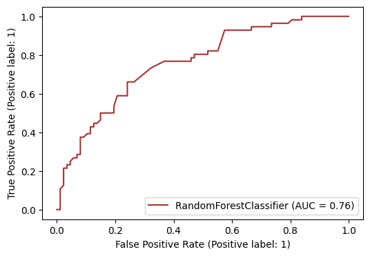

```python
# Plot ROC curve and calculate AUC
plt.figure(figsize=(6,4))
ax = plt.gca()
rfc_disp = RocCurveDisplay.from_estimator(rfc,
                                          X2_test,
                                          y2_test,
                                          ax=ax,
                                          alpha=0.8,
                                          c="darkred")
plt.show()
```

### Jupyter notebook --footer info-- (please always provide this at the end of each submitted notebook)

```python
import os
import platform
import socket
from platform import python_version
from datetime import datetime

print('-----------------------------------')
print(os.name.upper())
print(platform.system(), '|', platform.release())
print('Datetime:', datetime.now().strftime("%Y-%m-%d %H:%M:%S"))
print('Python Version:', python_version())
print('-----------------------------------')
```

```
-----------------------------------
NT
Windows | 10
Datetime: 2022-12-15 23:52:42
Python Version: 3.9.15
-----------------------------------
```